# Homework-Compilation

### Example 8.1

对EX8.1使用Cram´er-von Mises test：

```r
rm(list=ls())
library(twosamples)
library(goftest)
attach(chickwts)
x <- sort(as.vector(weight[feed == "soybean"]))
y <- sort(as.vector(weight[feed == "linseed"]))
detach(chickwts)

R <- 999;z <- c(x, y);K <- 1:26;n<-length(x)
set.seed(12345); method <- 2
reps <- numeric(R);t0 <- cvm_test(x, y)[1]
for (i in 1:R) {
  if(method==1){
    k <- sample(K, size = n, replace = FALSE)
    x1 <- z[k]; y1 <- z[-k] #complement of x1
  }else{
    xy <- sample(z);
    x1 <- xy[1:n]; y1 <- xy[-(1:n)]
  }
  reps[i] <-cvm_test(x1, y1)[1]
}
p <- mean(abs(c(t0, reps)) >= abs(t0))
round(c(cmvtest=p,cvm_test(x,y)[2]),3)
```

```
## cmvtest P-Value
##   0.398   0.401
```

对EX8.2使用Cram´er-von Mises test：

```r
rm(list=ls())
library(twosamples)
library(goftest)
library(twosamples)
attach(chickwts)
x <- sort(as.vector(weight[feed == "soybean"]))
y <- sort(as.vector(weight[feed == "linseed"]))
detach(chickwts)
R <- 999;z <- c(x, y);K <- 1:26;D<-numeric(R)
options(warn = -1)
D0 <- cvm_test(x, y)[1]
for (i in 1:R) {
  k <- sample(K, size = 14, replace = FALSE)
x1 <- z[k]
y1 <- z[-k]
D[i]<-cvm_test(x1, y1)[1]
}
p<-mean(c(D0,D)>=D0)
options(warn=0)
round(c(cvmtest=p,cvm_test(x,y)[2]),3)
```

```
## cvmtest P-Value
##   0.421   0.404
```

### Example 8.2

对原分布使用t-test,然后进行spearman检验

```r
rm(list=ls())
library(twosamples)
library(goftest)
attach(chickwts)
x <- sort(as.vector(weight[feed == "sunflower"]))
y <- sort(as.vector(weight[feed == "linseed"]))
detach(chickwts)

R <- 999;z <- c(x, y);K <- 1:26;n<-length(x);
set.seed(12345); method <- 2
reps <- numeric(R); t0 <- t.test(x, y)$statistic
for (i in 1:R) {
    xy <- sample(z);
    x1 <- xy[1:n]; y1 <- xy[-(1:n)]
  reps[i] <-t.test(x1, y1)$statistic
}
p1 <- mean(abs(c(t0, reps)) >= abs(t0))

reps1 <- numeric(R);t0 <- cor(x, y,method='spearman')
for (i in 1:R) {
  if(method==1){
    k <- sample(K, size = n, replace = FALSE)
    x1 <- z[k]; y1 <- z[-k] #complement of x1
  }else{
    xy <- sample(z);
    x1 <- xy[1:n]; y1 <- xy[-(1:n)]
  }
  reps1[i] <-cor(x1, y1,method='spearman')
}
p2 <- mean(abs(c(t0, reps1)) >= abs(t0))
round(c(p=p1,spearman_p=p2),5)
```

```
##          p spearman_p
##      0.001      0.001
```

结果相差不大

## Assignment 7

### Example 9.3

使用M-H采样对Cauchy分布的采样：

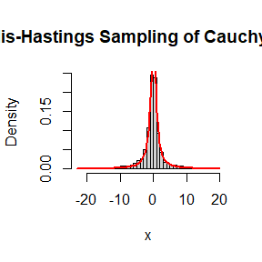

```r
set.seed(123)  # 设置随机种子以保证结果可重复

# 定义标准柯西分布的概率密度函数
dcauchy_standard <- function(x) {
  return(1 / (pi * (1 + x^2)))
}

# Metropolis-Hastings算法实现
metropolis_hastings <- function(start, iterations, proposal_sd, burn_in) {
  samples <- numeric(iterations)
  samples[1] <- start
  current_x <- start

  for (i in 2:iterations) {
    # 使用正态分布作为建议分布生成候选样本
    proposal_x <- rnorm(1, mean = current_x, sd = proposal_sd)

    # 计算接受概率
    acceptance_ratio <- dcauchy_standard(proposal_x) / dcauchy_standard(current_x)
    acceptance_probability <- min(1, acceptance_ratio)

    # 接受或拒绝候选样本
    if (runif(1) < acceptance_probability) {
      current_x <- proposal_x
    }

    samples[i] <- current_x
  }

  # 舍弃前burn_in个样本
  return(samples[(burn_in + 1):iterations])
}

# 使用Metropolis-Hastings算法进行抽样
start_value <- 0  # 初始值
iterations <- 11000  # 总迭代次数，包括烧入期
burn_in <- 1000  # 舍弃的初始样本数
proposal_sd <- 1  # 建议分布的标准差

samples <- metropolis_hastings(start_value, iterations, proposal_sd, burn_in)

# 绘制抽样结果的直方图
hist(samples, breaks = 50, probability = TRUE, main = "Metropolis-Hastings Sampling of Cauchy Distribution",
     xlab = "x", ylab = "Density")
curve(dcauchy_standard(x), add = TRUE, col = "red", lwd = 2)
```

### Example 9.8

得到如下的抽样图

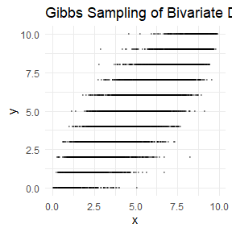

```r
# 加载必要的库
library(ggplot2)

# 定义参数
n <- 10  # 二项分布的试验次数
a <- 2   # Beta分布的参数a
b <- 2   # Beta分布的参数b
num_samples <- 10000  # 采样次数
burn_in <- 1000       # 烧入期

# 初始化
x_samples <- numeric(num_samples)
y_samples <- numeric(num_samples)
x_samples[1] <- rbeta(1, a, b) * n  # 初始x值
y_samples[1] <- rbinom(1, n, x_samples[1] / n)  # 初始y值

# 吉布斯采样
for (i in 2:num_samples) {
  # 从条件二项分布中采样y
  y_samples[i] <- rbinom(1, n, x_samples[i-1] / n)

  # 从条件Beta分布中采样x
  x_samples[i] <- rbeta(1, y_samples[i] + a, n - y_samples[i] + b) * n
}

# 丢弃烧入期样本
x_samples <- x_samples[-(1:burn_in)]
y_samples <- y_samples[-(1:burn_in)]

# 绘制样本的散点图
df <- data.frame(x = x_samples, y = y_samples)
ggplot(df, aes(x = x, y = y)) +
  geom_point(alpha = 0.3, size = 0.5) +
  labs(title = "Gibbs Sampling of Bivariate Distribution",
       x = "x", y = "y") +
  theme_minimal()
```

### 例题

GR检测合格

```r
# 安装coda包（如果尚未安装）
if (!requireNamespace("coda", quietly = TRUE)) {
  install.packages("coda")
}

# 加载coda包
library(coda)

# 定义参数
n <- 10
a <- 2
b <- 2
num_samples <- 10000
burn_in <- 1000
num_chains <- 3  # 运行的链数量

# 初始化存储链的列表
chains <- vector("list", num_chains)

# 运行多个独立的吉布斯采样链
for (chain in 1:num_chains) {
  x_samples <- numeric(num_samples)
  y_samples <- numeric(num_samples)
  x_samples[1] <- rbeta(1, a, b) * n
  y_samples[1] <- rbinom(1, n, x_samples[1] / n)

  for (i in 2:num_samples) {
    y_samples[i] <- rbinom(1, n, x_samples[i-1] / n)
    x_samples[i] <- rbeta(1, y_samples[i] + a, n - y_samples[i] + b) * n
  }

  # 丢弃烧入期样本
  x_samples <- x_samples[-(1:burn_in)]
  y_samples <- y_samples[-(1:burn_in)]

  # 将链存为mcmc对象
  chains[[chain]] <- mcmc(cbind(x_samples, y_samples))
}

# 计算Gelman-Rubin诊断
gelman_diag <- gelman.diag(mcmc.list(chains), autoburnin = FALSE)

# 输出Gelman-Rubin诊断结果
print(gelman_diag)
```

```
## Potential scale reduction factors:
##
##           Point est. Upper C.I.
## x_samples          1          1
## y_samples          1          1
##
## Multivariate psrf
##
## 1
```

```r
# 检查收敛性
if (all(gelman_diag$psrf[, "Point est."] < 1.2)) {
  cat("Chains have converged according to Gelman-Rubin diagnostic.\n")
} else {
  cat("Chains have NOT converged yet. Consider running for more iterations.\n")
}
```

```
## Chains have converged according to Gelman-Rubin diagnostic.
```

## Assignment 8

### Example 11.3

1. 原式$\frac{(-1)^{k}}{k!2^{k}} \frac{\|a\|^{2 k+2}}{(2 k+1)(2 k+2)} \frac{\Gamma\left(\frac{d+1}{2}\right) \Gamma\left(k+\frac{3}{2}\right)}{\Gamma\left(k+\frac{d}{2}+1\right)}$可改写为:$\frac{(-1)^{k}}{(2 k+1)(2 k+2)} \frac{\|a\|^{2 k+2}\Gamma\left(\frac{d+1}{2}\right) \Gamma\left(k+\frac{3}{2}\right)}{k!2^{k}\Gamma\left(k+\frac{d}{2}+1\right)}$，其中$\frac{\|a\|^{2 k+2}\Gamma\left(\frac{d+1}{2}\right) \Gamma\left(k+\frac{3}{2}\right)}{k!2^{k}\Gamma\left(k+\frac{d}{2}+1\right)}=e^{(2k+2)ln\|a\|+ln\Gamma(\frac{d+1}{2})+ln\Gamma\left(k+\frac{3}{2}\right)-kln2-\Sigma lnk-ln\Gamma\left(k+\frac{d}{2}+1\right)}$

```r
# 定义函数
k<-1000;
d<-100;
a<-c(1,2);
a_norm<-sqrt(sum(a^2))
resul<-((-1)^k / factorial(k) / (2^k)*(a_norm^(2 * k + 2)) / ((2 * k + 1) * (2 * k + 2))*gamma((d + 1) / 2) * gamma(k + 3 / 2) / gamma(k + d / 2 + 1))
term1<-(-1)^k / ((2 * k + 1) * (2 * k + 2))
term2 <- exp( (2*k+2)*log(a_norm,base=exp(1))+lgamma((d + 1) / 2)+lgamma(k + 3 / 2)- sum(log(1:k,base=exp(1))) -k*log(2,base=exp(1))-lgamma(k + d / 2 + 1))
resul1<-term1*term2
c(resul,resul1)
```

```
## [1] NaN   0
```

结果显示未经处理的结果显示为NaN，经处理后能正常显示。

```r
k<-1000;
d<-100;
term3<-numeric(1e3)
for(k in 1:1e3){
term1<-(-1)^k / ((2 * k + 1) * (2 * k + 2))
term2<-exp( (2*k+2)*log(a_norm,base=exp(1))+lgamma((d + 1) / 2)+lgamma(k + 3 / 2)- sum(log(1:k,base=exp(1))) -k*log(2,base=exp(1))-lgamma(k + d / 2 + 1))
term3[k]<-term1*term2
}
sumresul<-sum(term3)
sumresul
```

```
## [1] -0.00374078
```

3. 因为(2)已经将a设为(1,2)，所以得到的值就为-0.00374

### Example 11.5

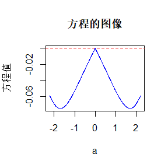

```r
# 加载必要的库
library(stats)

# 定义 k 的值
k <- 4  # 你可以根据需要修改这个值

# 定义 c_k 函数，增加对 a 的限制
c_k <- function(a, k) {
  if (a^2 >= k + 1) {
    return(NA)  # 返回 NA 以避免后续计算出错
  }
  return(sqrt(a^2 * k / (k + 1 - a^2)))
}

# 定义左侧的积分函数
left_integral <- function(a, k) {
  c_k_value <- c_k(a, k)
  if (is.na(c_k_value)) {
    return(NA)  # 如果 c_k_value 是 NA，返回 NA
  }

  integrand <- function(u) {
    (1 + u^2 / (k - 1))^(-k / 2)
  }
  integral_value <- integrate(integrand, 0, c_k_value)$value
  return((2 * gamma(k / 2) / sqrt(pi * (k - 1) * gamma((k - 1) / 2))) * integral_value)
}

# 定义右侧的积分函数
right_integral <- function(a, k) {
  c_k_value <- c_k(a, k)
  if (is.na(c_k_value)) {
    return(NA)  # 如果 c_k_value 是 NA，返回 NA
  }

  integrand <- function(u) {
    (1 + u^2 / k)^(-(k + 1) / 2)
  }
  integral_value <- integrate(integrand, 0, c_k_value)$value
  return((2 * gamma((k + 1) / 2) / (sqrt(pi * k) * gamma(k / 2))) * integral_value)
}

# 定义方程
equation <- function(a, k) {
  left <- left_integral(a, k)
  right <- right_integral(a, k)

  if (is.na(left) || is.na(right)) {
    return(NA)  # 如果任一侧是 NA，返回 NA
  }

  return(left - right)
}

# 绘制方程的图像以找到适合的范围
a_values <- seq(-sqrt(k + 1)+ 0.01, sqrt(k + 1) - 0.01, length.out = 1000)  # 限制 a 的上限
equation_values <- sapply(a_values, equation, k = k)

plot(a_values, equation_values, type = "l", col = "blue",
     xlab = "a", ylab = "方程值", main = "方程的图像")
abline(h = 0, col = "red", lty = 2)  # 添加 y=0 的参考线
```

```r
# 使用 uniroot 函数来找到 a 的解
# 请根据图像选择合适的范围
#a_solution <- uniroot(equation, c(-sqrt(k + 1)+ 0.01, sqrt(k + 1) - 0.01), k = k)  # 你可以根据需要调整范围
#cat("a 的解为:", a_solution$root, "\n")
a_solution <- uniroot(equation, c(0, 0.1), k = k)  # 你可以根据需要调整范围
cat("a 的解为:", a_solution$root, "\n")
```

```
## a 的解为: 0
```

通过计算可得，a离原点很近，当k很小的时候，求解是精确的，而当k较大时，伽马函数会发生突变，此时需要对伽马函数进行对数转化。

### 思考题

先通过EM算法：

```r
# 观察数据
Y <- c(0.54, 0.48, 0.33, 0.43, 1.00, 1.00, 0.91, 1.00, 0.21, 0.85)

# E-M 算法
em_algorithm <- function(Y, max_iter = 100, tol = 1e-6) {
  n <- length(Y)

  # 初始化 lambda
  lambda <- 1 / mean(Y[Y < 1])  # 基于观察数据的初始猜测

  for (iter in 1:max_iter) {
    # E 步：计算期望值
    # 计算给定 Y_i 的 T_i 的期望值
    expected_T <- ifelse(Y < 1, Y, 1)  # 对于 Y_i < 1, T_i = Y_i; 对于 Y_i = 1, T_i 是未知的
    expected_T[Y == 1] <- 1 + (1 / lambda)  # E[T | T > 1] = 1 + 1/lambda

    # M 步：更新 lambda
    lambda_new <- n / sum(expected_T)

    # 检查收敛性
    if (abs(lambda_new - lambda) < tol) {
      break
    }

    lambda <- lambda_new
  }

  return(lambda)
}

# 运行 E-M 算法
lambda_estimate <- em_algorithm(Y)
lambda_estimate
```

```
## [1] 1.037038
```

使用最大似然估计进行计算:

```r
# 计算 lambda 的 MLE
m <- sum(Y == 1)  # 删失观察值的数量
lambda_mle <- length(Y) / (sum(Y[Y < 1]) + m * 1)  # 在 tau = 1 处删失
lambda_mle
```

```
## [1] 1.481481
```

将两者进行比较:

```r
c('E-M'=lambda_estimate,'MLE'=lambda_mle)
```

```
##      E-M      MLE
## 1.037038 1.481481
```

## Assignment 9

### Exercise 11.7

```r
library(lpSolve)
library(knitr)

objective_coefficients <- c(4, 2, 9)

constraint_matrix <- matrix(c(2, 1, 1,
                              1, -1, 3),
                            nrow = 2, byrow = TRUE)

constraint_rhs <- c(2, 3)

constraint_directions <- c("<=", "<=")

# 解决线性规划问题，默认假设 x, y, z >= 0
lp_solution <- lp("min", objective_coefficients,
                  constraint_matrix, constraint_directions,
                  constraint_rhs, compute.sens = TRUE)

optimal_values <- lp_solution$solution
optimal_objective <- lp_solution$objval

# 创建结果数据框
result_table <- data.frame(
  Variables = c("x", "y", "z"),
  Optimal_Values = optimal_values,
  Objective_Value = optimal_objective
)

# 打印结果表格
kable(result_table, caption = "线性规划最优解结果")
```

线性规划最优解结果

| Variables | Optimal_Values | Objective_Value |
| --- | --- | --- |
| x | 0 | 0 |
| y | 0 | 0 |
| z | 0 | 0 |

### Exercise page204.3

```r
data(mtcars)

model_formulas <- list(
  mpg ~ disp,
  mpg ~ I(1 / disp),
  mpg ~ disp + wt,
  mpg ~ I(1 / disp) + wt
)

# 使用for循环
model_results_for <- list()
for (index in seq_along(model_formulas)) {
  model <- lm(model_formulas[[index]], data = mtcars)
  model_results_for[[index]] <- model
}

# 使用lapply
model_results_apply <- lapply(model_formulas, function(formula) {
  lm(formula, data = mtcars)
})

for (index in seq_along(model_results_apply)) {
  model <- model_results_apply[[index]]
  cat("Model", index, ":")
  cat("Coefficients:", coef(model), "\n")
  cat("R-squared:", summary(model)$r.squared, "\n")
  cat("p-value:", summary(model)$fstatistic[3], "\n\n")
}
```

```
## Model 1 :Coefficients: 29.59985 -0.04121512
## R-squared: 0.7183433
## p-value: 30
##
## Model 2 :Coefficients: 10.75202 1557.674
## R-squared: 0.8596865
## p-value: 30
##
## Model 3 :Coefficients: 34.96055 -0.01772474 -3.350825
## R-squared: 0.7809306
## p-value: 29
##
## Model 4 :Coefficients: 19.02421 1142.56 -1.797649
## R-squared: 0.8838038
## p-value: 29
```

### Exercise page204.4

创建fit_linear_model函数来拟合，不用匿名函数,结果如下表格：

```r
bootstraps <- lapply(1:10, function(i) {
  rows <- sample(1:nrow(mtcars), rep = TRUE)
  mtcars[rows, ]
})

fit_linear_model <- function(data) {
  lm(mpg ~ disp, data = data)
}

model_results <- lapply(bootstraps, fit_linear_model)

coefficients_df <- data.frame(
  Model = 1:length(model_results),
  Intercept = sapply(model_results, function(model) coef(model)[1]),
  Disp_Coefficient = sapply(model_results, function(model) coef(model)[2])
)

print(coefficients_df)
```

```
##    Model Intercept Disp_Coefficient
## 1      1  29.69268      -0.04446590
## 2      2  29.72130      -0.04174701
## 3      3  31.71861      -0.04639516
## 4      4  29.70625      -0.04315627
## 5      5  31.95297      -0.04652214
## 6      6  27.69524      -0.03526128
## 7      7  29.25101      -0.03728051
## 8      8  29.65108      -0.04015618
## 9      9  28.34283      -0.03700035
## 10    10  29.18731      -0.03852212
```

### Exercise page204.5

对于第一个模型，提取$R^2$:

```r
# 载入数据
data(mtcars)

# 定义模型公式
model_formulas <- list(
  mpg ~ disp,
  mpg ~ I(1 / disp),
  mpg ~ disp + wt,
  mpg ~ I(1 / disp) + wt
)

# 定义提取R²的函数
rsq <- function(mod) {
  summary(mod)$r.squared
}

# 使用lapply拟合模型并提取R²值
model_results_apply <- lapply(model_formulas, function(formula) {
  lm(formula, data = mtcars)
})

# 创建包含模型和R²值的数据框
results_df <- data.frame(
  Model = 1:length(model_results_apply),
  R_squared = sapply(model_results_apply, rsq)
)

# 打印结果
print(results_df)
```

```
##   Model R_squared
## 1     1 0.7183433
## 2     2 0.8596865
## 3     3 0.7809306
## 4     4 0.8838038
```

对于第二个模型，提取$R^2$:

```r
data(mtcars)

#bootstrap
bootstraps <- lapply(1:10, function(i) {
  rows <- sample(1:nrow(mtcars), replace = TRUE)
  mtcars[rows, ]
})


fit_linear_model <- function(data) {
  lm(mpg ~ disp, data = data)
}


model_results_for <- list()
for (i in seq_along(bootstraps)) {
  model_results_for[[i]] <- fit_linear_model(bootstraps[[i]])
}

# 使用lapply拟合模型
model_results_lapply <- lapply(bootstraps, fit_linear_model)


rsq <- function(mod) {
  summary(mod)$r.squared
}


r_squared_for <- sapply(model_results_for, rsq)
r_squared_lapply <- sapply(model_results_lapply, rsq)


results_df <- data.frame(
  Bootstrap_Sample = 1:10,
  R_squared_For = r_squared_for,
  R_squared_Lapply = r_squared_lapply
)

print(results_df)
```

```
##    Bootstrap_Sample R_squared_For R_squared_Lapply
## 1                 1     0.7242265        0.7242265
## 2                 2     0.7876236        0.7876236
## 3                 3     0.6816780        0.6816780
## 4                 4     0.7772465        0.7772465
## 5                 5     0.5987460        0.5987460
## 6                 6     0.7087358        0.7087358
## 7                 7     0.6994622        0.6994622
## 8                 8     0.5982239        0.5982239
## 9                 9     0.6540081        0.6540081
## 10               10     0.6629207        0.6629207
```

### Exercise page213.3

get rid of the anonymous function by using [[ directly.

```r
trials <- replicate(
  100,
  t.test(rpois(10, 10), rpois(7, 10)),
  simplify = FALSE
)
p_values_direct <- sapply(trials, `[[`, "p.value")
c("direct_p_mean"=mean(p_values_direct))
```

```
## direct_p_mean
##     0.4904223
```

### Exercise page214.6

创建一个函数结合map()和vapply(),用于并行，需要使用到FUN、每个FUN的VAPPLY模板:

```r
parallel_vapply <- function(FUN, ..., FUN.VALUE) {
  inputs <- list(...)
  results <- Map(FUN, ...)
  vapply(results, identity, FUN.VALUE)
}
```

### Exercise page365.4

直接使用pearson检验的定义来计算，只计算卡方统计量，代码如下(包含实例)：

```r
fast_chisq_test <- function(x, y) {


  observed <- table(x, y)

  # 期望频率
  row_totals <- rowSums(observed)
  col_totals <- colSums(observed)
  total <- sum(observed)
  expected <- outer(row_totals, col_totals) / total

  # 卡方统计量
  chisq_stat <- sum((observed - expected)^2 / expected)

  return(chisq_stat)
}

# Example
x <- c(1, 2, 1, 2, 1, 2,1,2,1,1)
y <- c(1, 1, 2, 2, 1, 2,1,1,2,1)
chisq_statistic <- fast_chisq_test(x, y)
print(chisq_statistic)
```

```
## [1] 0.2777778
```

### Exercise page365.5

直接构造频数表，并且用于加速chisq算法：

```r
fast_count_table <- function(vec1, vec2) {
  # 确保输入是整数向量
  stopifnot(is.integer(vec1), is.integer(vec2))

  # 找到唯一值并初始化频数矩阵
  count_matrix <- table(factor(vec1, levels = unique(vec1)),
                         factor(vec2, levels = unique(vec2)))

  return(count_matrix)
}

# 使用快速count_table()加速卡方检验
optimized_chisq_test <- function(vec1, vec2) {
  observed_counts <- fast_count_table(vec1, vec2)

  # 计算期望频率
  total_counts <- sum(observed_counts)
  expected_counts <- outer(rowSums(observed_counts), colSums(observed_counts)) / total_counts

  # 计算卡方统计量
  chi_square_stat <- sum((observed_counts - expected_counts)^2 / expected_counts)

  return(chi_square_stat)
}

# 示例
vector_a <- as.integer(c(1, 2, 1, 2, 1, 2))
vector_b <- as.integer(c(1, 1, 2, 2, 1, 2))
chi_square_result <- optimized_chisq_test(vector_a, vector_b)
print(chi_square_result)
```

```
## [1] 0.6666667
```

## Assignment 10

### Exercise 9.8 by Rcpp

写的Rcpp函数如下：

```cpp
#include <Rcpp.h>
using namespace Rcpp;

// [[Rcpp::export]]
List gibbs_sampler(int n, double a, double b, int num_samples, int burn_in) {
  // Initialize vectors to store samples
  NumericVector x_samples(num_samples);
  NumericVector y_samples(num_samples);

  // Initial values
  double x = R::rbeta(a, b) * n; // Initial x value
  int y = R::rbinom(n, x / n);   // Initial y value

  // Main Gibbs sampling loop
  for (int i = 0; i < num_samples + burn_in; ++i) {
    // Sample y | x from Binomial(n, x / n)
    y = R::rbinom(n, x / n);

    // Sample x | y from Beta(y + a, n - y + b)
    x = R::rbeta(y + a, n - y + b) * n;

    // Store samples after burn-in period
    if (i >= burn_in) {
      x_samples[i - burn_in] = x;
      y_samples[i - burn_in] = y;
    }
  }

  // Return samples as a list
  return List::create(Named("x_samples") = x_samples,
                      Named("y_samples") = y_samples);
}
```

[figure not shown]

```r
library(Rcpp)
library(ggplot2)
# 参数设置
n <- 20      # Binomial的试验次数
a <- 2       # Beta分布的参数
b <- 5       # Beta分布的参数
num_samples <- 5000  # 样本数量
burn_in <- 1000      # Burn-in阶段的样本数量

# 运行Gibbs采样
samples <- gibbs_sampler(n, a, b, num_samples, burn_in)

# 转换为数据框
df <- data.frame(x = samples$x_samples, y = samples$y_samples)

# 绘制二维分布的散点图
ggplot(df, aes(x = x, y = y)) +
  geom_point(alpha = 0.3, color = "red") +
  theme_minimal() +
  labs(title = "二维分布散点图",
       x = "x (Binomial Samples)",
       y = "y (Beta Samples)")
```

### Exercise 9.8 by R

之前写的

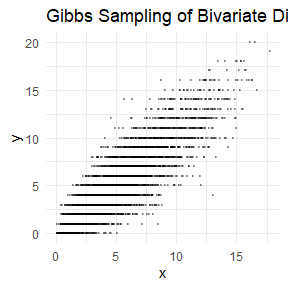

```r
# 加载必要的库
library(ggplot2)

# 参数设置
n <- 20      # Binomial的试验次数
a <- 2       # Beta分布的参数
b <- 5       # Beta分布的参数
num_samples <- 5000  # 样本数量
burn_in <- 1000      # Burn-in阶段的样本数量

# 初始化
x_samples <- numeric(num_samples)
y_samples <- numeric(num_samples)
#x_samples[1] <- rbeta(1, a, b) * n  # 初始x值
x_samples[1] <- n/2
y_samples[1] <-0.5
#y_samples[1] <- rbinom(1, n, x_samples[1] / n)  # 初始y值

# 吉布斯采样
for (i in 2:num_samples) {
  # 从条件二项分布中采样y
  y_samples[i] <- rbinom(1, n, x_samples[i-1] / n)

  # 从条件Beta分布中采样x
  x_samples[i] <- rbeta(1, y_samples[i] + a, n - y_samples[i] + b) * n
}

# 丢弃烧入期样本
x_samples <- x_samples[-(1:burn_in)]
y_samples <- y_samples[-(1:burn_in)]

# 绘制样本的散点图
df <- data.frame(x = x_samples, y = y_samples)
ggplot(df, aes(x = x, y = y)) +
  geom_point(alpha = 0.3, size = 0.5) +
  labs(title = "Gibbs Sampling of Bivariate Distribution",
       x = "x", y = "y") +
  theme_minimal()
```

现在开始用qqplot函数进行比较：

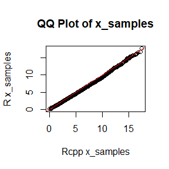

```r
# 从Rcpp函数获取样本
samples_rcpp <- gibbs_sampler(n, a, b, num_samples, burn_in)

# 提取Rcpp生成的样本
x_samples_rcpp <- samples_rcpp$x_samples
y_samples_rcpp <- samples_rcpp$y_samples
# 比较x_samples
qqplot(x_samples_rcpp, x_samples, main = "QQ Plot of x_samples",
       xlab = "Rcpp x_samples", ylab = "R x_samples")
abline(0, 1, col = "red")
```

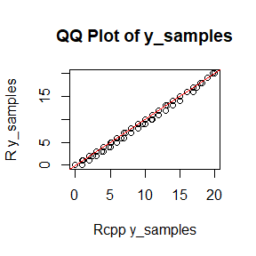

```r
# 比较y_samples
qqplot(y_samples_rcpp, y_samples, main = "QQ Plot of y_samples",
       xlab = "Rcpp y_samples", ylab = "R y_samples")
abline(0, 1, col = "red")
```

### 计算时间比较:

```r
# Load necessary libraries
library(Rcpp)
library(microbenchmark)

# Source the Rcpp code
#sourceCpp("path_to_your_rcpp_file.cpp")  # Replace with the actual path to your Rcpp file

# Define the R function for Gibbs sampling
gibbs_sampler_r <- function(n, a, b, num_samples, burn_in) {
  x_samples <- numeric(num_samples)
  y_samples <- numeric(num_samples)
  x_samples[1] <- n / 2
  y_samples[1] <- 0.5

  for (i in 2:num_samples) {
    y_samples[i] <- rbinom(1, n, x_samples[i-1] / n)
    x_samples[i] <- rbeta(1, y_samples[i] + a, n - y_samples[i] + b) * n
  }

  x_samples <- x_samples[-(1:burn_in)]
  y_samples <- y_samples[-(1:burn_in)]

  list(x_samples = x_samples, y_samples = y_samples)
}

# Set parameters
n <- 20
a <- 2
b <- 5
num_samples <- 5000
burn_in <- 1000

# Run microbenchmark
benchmark_results <- microbenchmark(
  Rcpp = gibbs_sampler(n, a, b, num_samples, burn_in),
  R = gibbs_sampler_r(n, a, b, num_samples, burn_in),
  times = 10
)

# Print benchmark results
print(benchmark_results)
```

```
## Unit: milliseconds
##  expr    min     lq    mean median     uq     max neval
##  Rcpp 1.0297 1.0468 1.07625 1.0872 1.0945  1.1144    10
##     R 6.5706 6.8682 8.30366 7.3249 9.3255 13.7192    10
```

### Comments:

1. Rcpp的代码在所有统计指标上都表现出更快的执行速度。最小、中位数和最大时间都显著低于R语言实现，表明Rcpp在速度上具有明显优势。 稳定性：
2. Rcpp的运行时间分布较为集中，最大时间与最小时间的差距较小，表明其在多次运行中的性能较为稳定。 R语言的运行时间在最大值和最小值之间的差距较大，显示出更大的波动性，特别是在最大时间上，R语言的实现显著慢于Rcpp。